# Venn Demo Programming Code

Detlef Groth

2022-01-30

## Introduction

This is a demo on how to create a Venn diagram from scratch having just two lists of items. Let’s start with creating some example data:

```r
v1=sprintf("gene_%03i",1:40)
v2=c(c("gene_001","gene_002","gene_002","gene_002"),
    sprintf("gene_%03i",38:48),rep("",25))
data.sam=data.frame(v1,v2)

head(data.sam)
```

```
##         v1       v2
## 1 gene_001 gene_001
## 2 gene_002 gene_002
## 3 gene_003 gene_002
## 4 gene_004 gene_002
## 5 gene_005 gene_038
## 6 gene_006 gene_039
```

```r
tail(data.sam)
```

```
##          v1 v2
## 35 gene_035
## 36 gene_036
## 37 gene_037
## 38 gene_038
## 39 gene_039
## 40 gene_040
```

```r
nrow(data.sam)
```

```
## [1] 40
```

This data might represent up regulated genes in to sets, let’s say mutant and wild-type gene expressions after heatshock experiments for instance. In set v1 more genes were up-regulated than in the set v2. That’s why the second columns was filled up with empty strings.

Let’s create a vector with unique genenames. How many we have?

```r
length(unique(union(data.sam[,1],data.sam[,2])))
```

```
## [1] 49
```

How many items we have in the second row:

```r
length(which(data.sam[,2]!=""))
```

```
## [1] 15
```

Ok, very few! So the overlap should be small:

The data with the empty string might later make problems. We do not see anything in the output. Let’s set them to NA, that makes more clear what is going on.

```r
data.sam[,2][data.sam[,2]==""]=NA
tail(data.sam)
```

```
##          v1   v2
## 35 gene_035 <NA>
## 36 gene_036 <NA>
## 37 gene_037 <NA>
## 38 gene_038 <NA>
## 39 gene_039 <NA>
## 40 gene_040 <NA>
```

```r
unique(union(data.sam[,1],data.sam[,2]))
```

```
##  [1] "gene_001" "gene_002" "gene_003" "gene_004" "gene_005" "gene_006"
##  [7] "gene_007" "gene_008" "gene_009" "gene_010" "gene_011" "gene_012"
## [13] "gene_013" "gene_014" "gene_015" "gene_016" "gene_017" "gene_018"
## [19] "gene_019" "gene_020" "gene_021" "gene_022" "gene_023" "gene_024"
## [25] "gene_025" "gene_026" "gene_027" "gene_028" "gene_029" "gene_030"
## [31] "gene_031" "gene_032" "gene_033" "gene_034" "gene_035" "gene_036"
## [37] "gene_037" "gene_038" "gene_039" "gene_040" "gene_041" "gene_042"
## [43] "gene_043" "gene_044" "gene_045" "gene_046" "gene_047" "gene_048"
## [49] NA
```

```r
length(intersect(data.sam[,1],data.sam[,2]))
```

```
## [1] 5
```

The difference sets we get using the `setdiff` function:

```r
setdiff(data.sam[,2],data.sam[,1])
```

```
## [1] "gene_041" "gene_042" "gene_043" "gene_044" "gene_045" "gene_046" "gene_047"
## [8] "gene_048" NA
```

```r
# still the NA is  hanging around
length(which(!is.na(setdiff(data.sam[,1],data.sam[,2]))))
```

```
## [1] 35
```

```r
length(which(!is.na(setdiff(data.sam[,2],data.sam[,1]))))
```

```
## [1] 8
```

That looks strange, we would expect that the numbers from the difference set and the intersection should match the number of items in the second set, are there duplicates in the second set??

```r
head(rev(sort(table(data.sam[,2]))),n=10)
```

```
##
## gene_002 gene_048 gene_047 gene_046 gene_045 gene_044 gene_043 gene_042
##        3        1        1        1        1        1        1        1
## gene_041 gene_040
##        1        1
```

So, yes there are multiple entries in the second column. Is this right? It might be that one gene is found several times on several places in the genome, for instance t-RNA genes are known to appear several times in the genome.

Hint: Careful inspection of your data for anomalies is an important point in reserarch! make sure that your data is OK!

## The Plot

Let’s continue. First we give some more meaningful column names.

```r
colnames(data.sam)=c("Mutant","Wildtyp")
```

Let’s now prepare a simple Venn diagram, we will just use a large plotting character, which one might be appropiate?

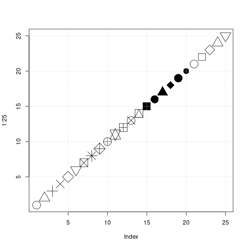

```r
plot(1:25,pch=1:25,cex=3)
grid()
```

Character 19 is our favourite. Let’s plot an empty plot first without axes and labels and then add two large plotting chars.

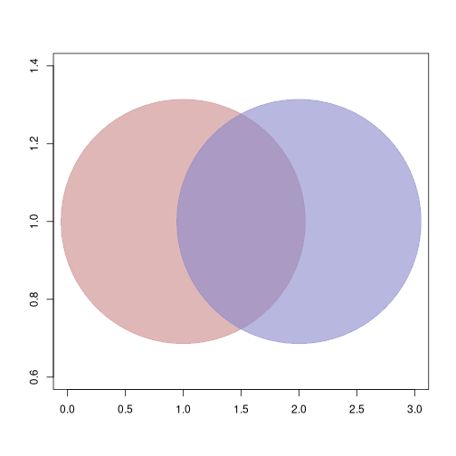

```r
plot(c(1,2),c(1,1),xlim=c(0,3),pch=19,cex=50,xlab="",ylab="",
    col=c("#cc888899","#8888cc99"))
```

Great, we now see the positions where we can place our numbers and labels. We need a little bit more space on top, so we set the ylim slightly larger. In our example there will be no outer number as we have only items which are in one of the sets. However, we might later reserve some space for numbers counting items which are in none of the two sets.

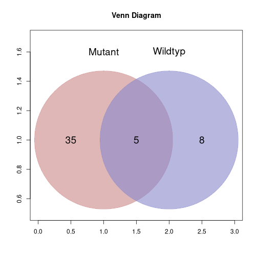

```r
plot(c(1,2),c(1,1),xlim=c(0,3),ylim=c(0.5,1.7),
    pch=19,cex=50,
    xlab="",ylab="",
    col=c("#cc888899","#8888cc99"))
title("Venn Diagram")
text(1,1.6,colnames(data.sam)[1],cex=1.6)
text(2,1.6,colnames(data.sam)[2],cex=1.6)
text(1.5,1,length(which(!is.na(intersect(data.sam[,1],data.sam[,2])))),cex=1.6)
text(0.5,1,length(which(!is.na(setdiff(data.sam[,1],data.sam[,2])))),cex=1.6)
text(2.5,1,length(which(!is.na(setdiff(data.sam[,2],data.sam[,1])))),cex=1.6)
```

We can remove the axes and the box by using axes=FALSE as an argument to the plot parameter. And then we should wrap the code in the function to create more easily all our next Venn diagrams.

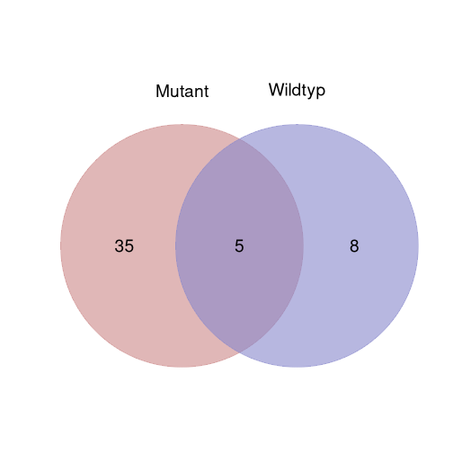

```r
sebsVenn = function (x,col=c("#cc888899","#8888cc99"),cex=1.6,...) {
    if (!is.data.frame(x) & !is.matrix(x)) {
        stop("Error: Not a two column matrix or data frame!")
    }
    if (ncol(x) != 2) {
        stop("Error: Not a two column matrix or data frame!")
    }
    plot(c(1,2),c(1,1),xlim=c(0,3),ylim=c(0.5,1.7),
         pch=19,cex=50,axes=FALSE,
            xlab="",ylab="",
            col=col,...)
    x[,1][x[,1]==""]=NA
    x[,2][x[,2]==""]=NA
    text(1,1.6,colnames(x)[1],cex=cex)
    text(2,1.6,colnames(x)[2],cex=cex)
    text(1.5,1,length(which(!is.na(intersect(x[,1],x[,2])))),cex=cex)
    text(0.5,1,length(which(!is.na(setdiff(x[,1],x[,2])))),cex=cex)
    text(2.5,1,length(which(!is.na(setdiff(x[,2],x[,1])))),cex=cex)
}
sebsVenn(data.sam)
```

We can still change the plotting character size and give the diagram a title as all remaining arguments are delegated to the plot function.

```r
sebsVenn(data.sam,cex=1.8,main="Sample Venn Diagram",cex.main=2)
```

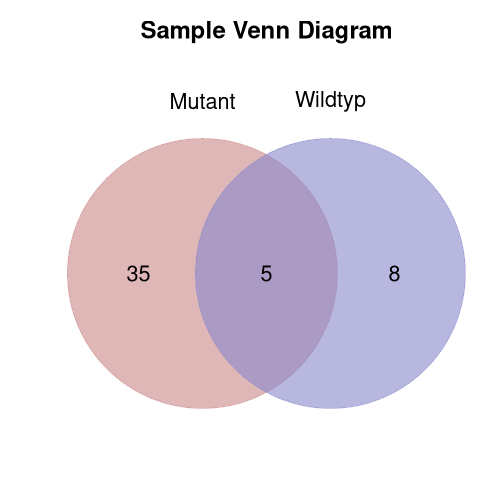

If we have such a function we can now appy this function on any type of data, let’s create some sample data which should be always done to check the validity of the code and that the code is reusable for other data.

```r
set.seed(12345) ;# to get always the same random sets
vec1=sample(LETTERS,10)
vec2=sample(LETTERS,10)
sort(vec1)
```

```
##  [1] "B" "F" "G" "J" "K" "N" "P" "Q" "S" "W"
```

```r
sort(vec2)
```

```
##  [1] "A" "C" "F" "G" "H" "I" "L" "T" "V" "Z"
```

```r
sort(intersect(vec1,vec2))
```

```
## [1] "F" "G"
```

Ok,that are good sample data. Let’s create a data frame and the check our `sebsVenn` function.

```r
df.test=data.frame(Vec1=vec1,Vec2=vec2)
head(df.test)
```

```
##   Vec1 Vec2
## 1    N    H
## 2    S    G
## 3    P    F
## 4    K    A
## 5    B    L
## 6    W    T
```

```r
sebsVenn(df.test,main="Test Data Venn",cex.main=2)
```

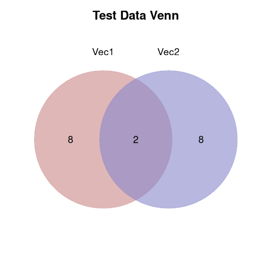

You can now copy the function `sebsVenn` into your own R-code and use it for your own data.

## New data format

Sometimes our input format lools different, we might have in the columns numerical values which are transposed to TRUE/FALSE, so a boolean value like below:

```r
rn1=rnorm(10)
rn2=rnorm(10,mean=0.5)
data.num=data.frame(Rn1=rn1,Rn2=rn2)
rownames(data.num)=paste("Gene",1:length(rn1),sep="_")
head(data.num)
```

```
##               Rn1        Rn2
## Gene_1 -0.8863575 0.01835264
## Gene_2 -0.3315776 1.12037980
## Gene_3  1.1207127 1.11212349
## Gene_4  0.2987237 0.33768902
## Gene_5  0.7796219 1.31187318
## Gene_6  1.4557851 2.69683355
```

Let’s now trampose this too a boolean data frame:

```r
data.bool=data.num>0.5
data.bool
```

```
##           Rn1   Rn2
## Gene_1  FALSE FALSE
## Gene_2  FALSE  TRUE
## Gene_3   TRUE  TRUE
## Gene_4  FALSE FALSE
## Gene_5   TRUE  TRUE
## Gene_6   TRUE  TRUE
## Gene_7  FALSE  TRUE
## Gene_8  FALSE  TRUE
## Gene_9  FALSE  TRUE
## Gene_10  TRUE  TRUE
```

We would like now to create a Venn diagram for such tables. So we have to extend our Venn function so that it accepts as well tables where the columns contain boolean values.

The intersection would be then based on the rows where both values are TRUE.

```r
data.bool[,1] & data.bool[,2]
```

```
##  Gene_1  Gene_2  Gene_3  Gene_4  Gene_5  Gene_6  Gene_7  Gene_8  Gene_9 Gene_10
##   FALSE   FALSE    TRUE   FALSE    TRUE    TRUE   FALSE   FALSE   FALSE    TRUE
```

```r
# intersection
length(which(data.bool[,1] & data.bool[,2]))
```

```
## [1] 4
```

```r
# left set
length(which(data.bool[,1] & !data.bool[,2]))
```

```
## [1] 0
```

```r
# right set
length(which(!data.bool[,1] & data.bool[,2]))
```

```
## [1] 4
```

```r
# outer set
length(which(!data.bool[,1] & !data.bool[,2]))
```

```
## [1] 2
```

Ok, so we can compute the values. We now modify our function above, so that it know differentiates between the data formats boolean and string and then computes separately the numbers and does finally the plot. Here this version:

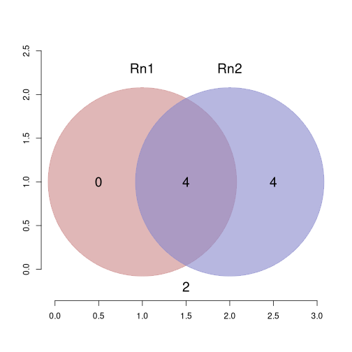

```r
delfsVenn = function (x,col=c("#cc888899","#8888cc99"),cex=1.6,...) {
    if (!is.data.frame(x) & !is.matrix(x)) {
        stop("Error: Not a two column matrix or data frame!")
    }
    if (ncol(x) != 2) {
        stop("Error: Not a two column matrix or data frame!")
    }
    plot(c(1,2),c(1,1),xlim=c(0,3),ylim=c(-0.25,2.5),
         pch=19,cex=50,axes=FALSE,
            xlab="",ylab="",asp=1,
            col=col,...)
    # the changes
    if (class(x[,1]) == "logical") {
        is=length(which(x[,1] & x[,2]))
        ls=length(which(x[,1] & !x[,2]))
        rs=length(which(!x[,1] & x[,2]))
        os=length(which(!x[,1] & !x[,2]))
    } else {
        is=length(intersect(x[,1],x[,2]))
        ls=length(setdiff(x[,1],x[,2]))
        rs=length(setdiff(x[,2],x[,1]))
        os=""
    }
    text(1,2.3,colnames(x)[1],cex=cex)
    text(2,2.3,colnames(x)[2],cex=cex)

    text(1.5,1,is,cex=cex)
    text(0.5,1,ls,cex=cex)
    text(2.5,1,rs,cex=cex)
    text(1.5,-0.2,os,cex=cex)
}
delfsVenn(data.bool)
axis(1)
axis(2)
```

This function can now take any table which has one of the two different formats. It is generic for any data and also more flexible for the input data. It is even more reusable than the version before.

## Fixing the aspect issue

Our code with the venn has one problem: if the figure space which is available is not square like our Venn diagram get’s confused. Here an example with fig.width=5 and fig.height=5:

```r
delfsVenn(data.bool)
```

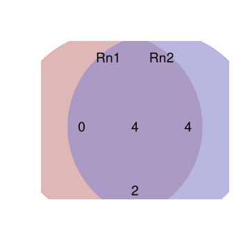

The same effect could happend if the users uses different figure margins or changes the size of the figure in interactive session. Here the result with a figure size of width and height of 7 inches but setting a larger margin than the default:

```r
par(mai=rep(1,4))
delfsVenn(data.bool)
axis(1)
axis(2)
```

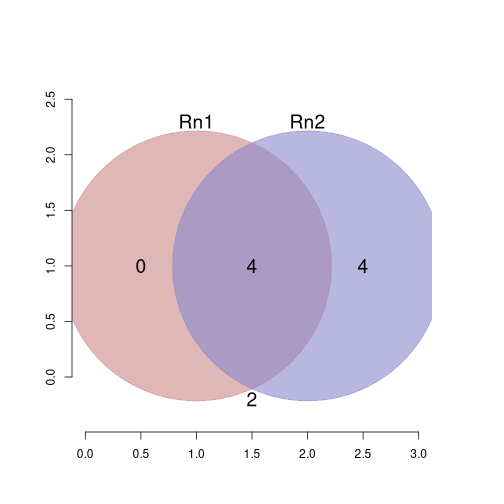

We can fix this issue by manually setting the y-dimension to same before we start the plot and by setting the margins to the defaults and using the device width in inches for the calculation of the size of the plotting character for the circles. Further we calculate the circle size dynamically based on the available dimensions of the figure.

```r
delfsVenn = function (x,col=c("#cc888899","#8888cc99"),cex=1.6,...) {
    if (!is.data.frame(x) & !is.matrix(x)) {
        stop("Error: Not a two column matrix or data frame!")
    }
    if (ncol(x) != 2) {
        stop("Error: Not a two column matrix or data frame!")
    }
    # reset to useful values, slightly smaller than the defaults:
    # defaults: mai=c(1.02, 0.82, 0.82, 0.42)
    opar=par(mai=c(1, 0.8, 0.8, 0.4))
    # compute circle size
    circ.cex=50*par()$fin[1]/9
    plot(c(1,2),c(1,1),xlim=c(0,3),ylim=c(0.4,1.7),
         pch=19,cex=circ.cex,axes=FALSE,
            xlab="",ylab="",
            col=col,...)
    text(1,1.6,colnames(x)[1],cex=cex)
    text(2,1.6,colnames(x)[2],cex=cex)
    # the changes
    if (class(x[,1]) == "logical") {
        is=length(which(x[,1] & x[,2]))
        ls=length(which(x[,1] & !x[,2]))
        rs=length(which(!x[,1] & x[,2]))
        os=length(which(!x[,1] & !x[,2]))
    } else {
        is=length(intersect(x[,1],x[,2]))
        ls=length(setdiff(x[,1],x[,2]))
        rs=length(setdiff(x[,2],x[,1]))
        os=""
    }
    text(1.5,1,is,cex=cex)
    text(0.5,1,ls,cex=cex)
    text(2.5,1,rs,cex=cex)
    text(1.5,0.4,os,cex=cex)
    par(opar)
}
```

Now let’s try a 5/5 figure

```r
delfsVenn(data.bool)
```

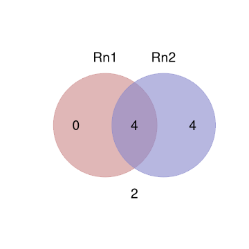

And now a 9/9 figure:

```r
delfsVenn(data.bool,cex=3)
```

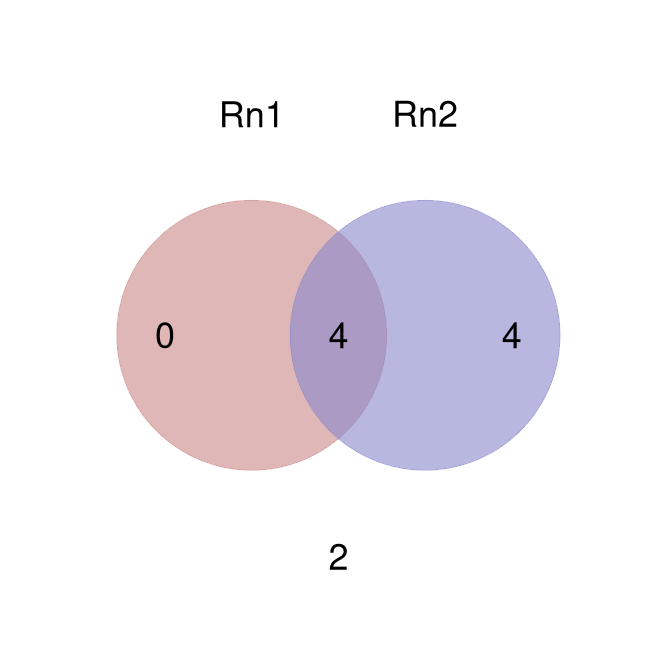

Obviously you still detoriate the layout by creating a 4/9 figure, but who should do this?

Let’s finally try to combine two Venn diagrams side by side where we indeed have to set fig.width to the double of fig.height:

```r
par(mfrow=c(1,2))
delfsVenn(data.bool,main="bool1",cex=2.1,cex.main=2)
data.bool2=data=data.num<0.25
delfsVenn(data.bool2,main="bool2",cex=2.1,cex.main=2,col=c("#cccc8899","#8888cc99"))
```

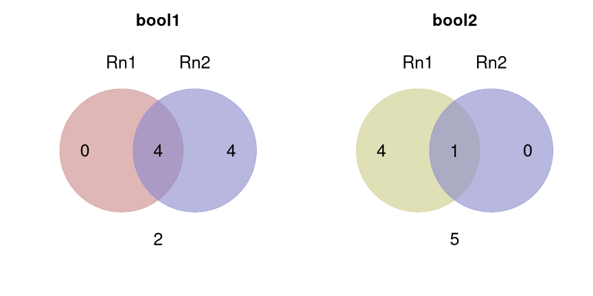

### Conclusion

Ok, our Venn diagram is now more robust in changing the figure size. We still have to keep this constant, but as long as we do this we are save. It would be as well possible to fix the issue with non-quadratic layouts, but that would be slightly too much burden.

## Homework

As an exercise I give you the task to allow as well a two vector input like this:

```r
vec1=LETTERS[1:8]
vec2=LETTERS[4:10]
vec1
```

```
## [1] "A" "B" "C" "D" "E" "F" "G" "H"
```

```r
vec2
```

```
## [1] "D" "E" "F" "G" "H" "I" "J"
```

So our function hwVenn should have something like the following layout:

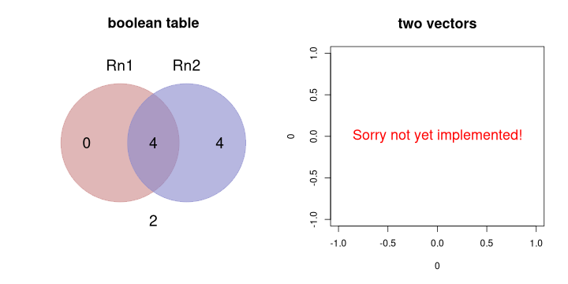

```r
hwVenn = function (x,y=NULL,...) {
    if (is.data.frame(x) | is.matrix(x)) {
        delfsVenn(x,...)
    } else {
        plot(0,0,type="n",...)
        text(0,0,"Sorry not yet implemented!",col="red",cex=1.5)
        # two vector case!!
        # check if y is not null
        # create data frame compatible for delfVenn
        # call delfVenn with this data frame
        # replace the dummy Sorry plot with this call
    }
}
par(mfrow=c(1,2))
hwVenn(data.bool,main="boolean table",cex.main=1.5)
hwVenn(vec1,vec2,main="two vectors",cex.main=1.5)
```